# Topic ideas - Data

Group name: Gruppe C  
Group members: Lena Binder, Julian Kulinsky, Sven Ritzmann

## Recommendations for Cinema’s-Best-Event

### Data source

Source: IMDB; The data was collected by IMDB and is two years old at the current time, so was collected in 2020.

### Data characterisitcs

The dataset contains information about movies. In total there are 1000 observations and 16 columns. For each movie the data includes the following features: Link to the movie poster, title, release year, certificate, runtime, genre, IMDB rating, overview, meta score, director, stars, votes and gross earning.

### Question

Which movies were most popular in the past years? Which genre was most popular? -> Select the best movies for a Cinemas-Best-Event

### Overview of data

```python
import pandas as pd
import seaborn as sns

movies_cinema = pd.read_csv('../data/raw/movies_cinema.csv')
```

```python
movies_cinema.info()
```

```
<class 'pandas.core.frame.DataFrame'>
RangeIndex: 1000 entries, 0 to 999
Data columns (total 16 columns):
 #   Column         Non-Null Count  Dtype
---  ------         --------------  -----
 0   Poster_Link    1000 non-null   object
 1   Series_Title   1000 non-null   object
 2   Released_Year  1000 non-null   object
 3   Certificate    899 non-null    object
 4   Runtime        1000 non-null   object
 5   Genre          1000 non-null   object
 6   IMDB_Rating    1000 non-null   float64
 7   Overview       1000 non-null   object
 8   Meta_score     843 non-null    float64
 9   Director       1000 non-null   object
 10  Star1          1000 non-null   object
 11  Star2          1000 non-null   object
 12  Star3          1000 non-null   object
 13  Star4          1000 non-null   object
 14  No_of_Votes    1000 non-null   int64
 15  Gross          831 non-null    object
dtypes: float64(2), int64(1), object(13)
memory usage: 125.1+ KB
```

```python
movies_cinema.describe()
```

|  | IMDB_Rating | Meta_score | No_of_Votes |
| --- | --- | --- | --- |
| count | 1000.000000 | 843.000000 | 1.000000e+03 |
| mean | 7.949300 | 77.971530 | 2.736929e+05 |
| std | 0.275491 | 12.376099 | 3.273727e+05 |
| min | 7.600000 | 28.000000 | 2.508800e+04 |
| 25% | 7.700000 | 70.000000 | 5.552625e+04 |
| 50% | 7.900000 | 79.000000 | 1.385485e+05 |
| 75% | 8.100000 | 87.000000 | 3.741612e+05 |
| max | 9.300000 | 100.000000 | 2.343110e+06 |

```python
movies_cinema.head()
```

|  | Poster_Link | Series_Title | Released_Year | Certificate | Runtime | Genre | IMDB_Rating | Overview | Meta_score | Director | Star1 | Star2 | Star3 | Star4 | No_of_Votes | Gross |
| --- | --- | --- | --- | --- | --- | --- | --- | --- | --- | --- | --- | --- | --- | --- | --- | --- |
| 0 | https://m.media-amazon.com/images/M/MV5BMDFkYT... | The Shawshank Redemption | 1994 | A | 142 min | Drama | 9.3 | Two imprisoned men bond over a number of years... | 80.0 | Frank Darabont | Tim Robbins | Morgan Freeman | Bob Gunton | William Sadler | 2343110 | 28,341,469 |
| 1 | https://m.media-amazon.com/images/M/MV5BM2MyNj... | The Godfather | 1972 | A | 175 min | Crime, Drama | 9.2 | An organized crime dynasty's aging patriarch t... | 100.0 | Francis Ford Coppola | Marlon Brando | Al Pacino | James Caan | Diane Keaton | 1620367 | 134,966,411 |
| 2 | https://m.media-amazon.com/images/M/MV5BMTMxNT... | The Dark Knight | 2008 | UA | 152 min | Action, Crime, Drama | 9.0 | When the menace known as the Joker wreaks havo... | 84.0 | Christopher Nolan | Christian Bale | Heath Ledger | Aaron Eckhart | Michael Caine | 2303232 | 534,858,444 |
| 3 | https://m.media-amazon.com/images/M/MV5BMWMwMG... | The Godfather: Part II | 1974 | A | 202 min | Crime, Drama | 9.0 | The early life and career of Vito Corleone in ... | 90.0 | Francis Ford Coppola | Al Pacino | Robert De Niro | Robert Duvall | Diane Keaton | 1129952 | 57,300,000 |
| 4 | https://m.media-amazon.com/images/M/MV5BMWU4N2... | 12 Angry Men | 1957 | U | 96 min | Crime, Drama | 9.0 | A jury holdout attempts to prevent a miscarria... | 96.0 | Sidney Lumet | Henry Fonda | Lee J. Cobb | Martin Balsam | John Fiedler | 689845 | 4,360,000 |

## Future licenses for Netflix to gain competitive advantage

### Data source

Source: IMDB The data was collected in August 2022 by IMDB.

### Data characterisitcs

The dataset contains information about movies. In total there are 5000 observations and 11 columns. For each movie the data includes the following features: Link to the movie poster, title, certificate, runtime, genre, IMDB rating, overview, director, stars, votes and gross earning.

### Question

Which movies are popular at the moment and what are the most-promising movies to show in order to increase profabitility and attract new users?

### Overview of data

```python
movies_netflix = pd.read_csv('../data/raw/movies_netflix.csv')
```

```python
movies_netflix.info()
```

```
<class 'pandas.core.frame.DataFrame'>
RangeIndex: 5000 entries, 0 to 4999
Data columns (total 11 columns):
 #   Column       Non-Null Count  Dtype
---  ------       --------------  -----
 0   poster       5000 non-null   object
 1   title        5000 non-null   object
 2   certificate  5000 non-null   object
 3   runtime      5000 non-null   object
 4   genre        4970 non-null   object
 5   rating       5000 non-null   float64
 6   about        4986 non-null   object
 7   director     5000 non-null   object
 8   stars        5000 non-null   object
 9   votes        5000 non-null   object
 10  gross_earn   4585 non-null   object
dtypes: float64(1), object(10)
memory usage: 429.8+ KB
```

```python
movies_netflix.describe()
```

|  | rating |
| --- | --- |
| count | 5000.000000 |
| mean | 6.692300 |
| std | 0.973649 |
| min | 1.500000 |
| 25% | 6.100000 |
| 50% | 6.800000 |
| 75% | 7.400000 |
| max | 9.300000 |

```python
movies_netflix.head()
```

|  | poster | title | certificate | runtime | genre | rating | about | director | stars | votes | gross_earn |
| --- | --- | --- | --- | --- | --- | --- | --- | --- | --- | --- | --- |
| 0 | https://m.media-amazon.com/images/S/sash/4Fyxw... | The Shawshank Redemption | 15 | 142 min | Drama | 9.3 | Two imprisoned men bond over a number of years... | Frank Darabont | ('Tim Robbins',), ('Morgan Freeman',), ('Bob G... | 26,26,905 | $28.34M |
| 1 | https://m.media-amazon.com/images/S/sash/4Fyxw... | The Dark Knight | 12A | 152 min | Action, Crime, Drama | 9.0 | When the menace known as the Joker wreaks havo... | Christopher Nolan | ('Christian Bale',), ('Heath Ledger',), ('Aaro... | 25,98,173 | $534.86M |
| 2 | https://m.media-amazon.com/images/S/sash/4Fyxw... | Inception | 12A | 148 min | Action, Adventure, Sci-Fi | 8.8 | A thief who steals corporate secrets through t... | Christopher Nolan | ('Leonardo DiCaprio',), ('Joseph Gordon-Levitt... | 23,04,062 | $292.58M |
| 3 | https://m.media-amazon.com/images/S/sash/4Fyxw... | Fight Club | 18 | 139 min | Drama | 8.8 | An insomniac office worker and a devil-may-car... | David Fincher | ('Brad Pitt',), ('Edward Norton',), ('Meat Loa... | 20,71,088 | $37.03M |
| 4 | https://m.media-amazon.com/images/S/sash/4Fyxw... | Pulp Fiction | 18 | 154 min | Crime, Drama | 8.9 | The lives of two mob hitmen, a boxer, a gangst... | Quentin Tarantino | ('John Travolta',), ('Uma Thurman',), ('Samuel... | 20,11,013 | $107.93M |

## IBM Employee Attrition & Performance

### Data source

Source: IBM (Kaggle)

### Data characterisitcs

The dataset contains information about employee attrition and performance. In total there are 1470 observations and 35 columns. For each employee the data includes information about the age, department, education, gender, hourly rate, job level and job role etc. Further features can be retrieved by executing employees.info()

### Question

How to improve employee satisfaction across departments and what are current key drivers for decreasing job satisfaction?

### Overview of data

```python
employees = pd.read_csv('../data/raw/employee.csv')
```

```python
employees.info()
```

```
<class 'pandas.core.frame.DataFrame'>
RangeIndex: 1470 entries, 0 to 1469
Data columns (total 35 columns):
 #   Column                    Non-Null Count  Dtype
---  ------                    --------------  -----
 0   Age                       1470 non-null   int64
 1   Attrition                 1470 non-null   object
 2   BusinessTravel            1470 non-null   object
 3   DailyRate                 1470 non-null   int64
 4   Department                1470 non-null   object
 5   DistanceFromHome          1470 non-null   int64
 6   Education                 1470 non-null   int64
 7   EducationField            1470 non-null   object
 8   EmployeeCount             1470 non-null   int64
 9   EmployeeNumber            1470 non-null   int64
```

[output cut: 27 more lines]

```python
employees.describe()
```

|  | Age | DailyRate | DistanceFromHome | Education | EmployeeCount | EmployeeNumber | EnvironmentSatisfaction | HourlyRate | JobInvolvement | JobLevel | ... | RelationshipSatisfaction | StandardHours | StockOptionLevel | TotalWorkingYears | TrainingTimesLastYear | WorkLifeBalance | YearsAtCompany | YearsInCurrentRole | YearsSinceLastPromotion | YearsWithCurrManager |
| --- | --- | --- | --- | --- | --- | --- | --- | --- | --- | --- | --- | --- | --- | --- | --- | --- | --- | --- | --- | --- | --- |
| count | 1470.000000 | 1470.000000 | 1470.000000 | 1470.000000 | 1470.0 | 1470.000000 | 1470.000000 | 1470.000000 | 1470.000000 | 1470.000000 | ... | 1470.000000 | 1470.0 | 1470.000000 | 1470.000000 | 1470.000000 | 1470.000000 | 1470.000000 | 1470.000000 | 1470.000000 | 1470.000000 |
| mean | 36.923810 | 802.485714 | 9.192517 | 2.912925 | 1.0 | 1024.865306 | 2.721769 | 65.891156 | 2.729932 | 2.063946 | ... | 2.712245 | 80.0 | 0.793878 | 11.279592 | 2.799320 | 2.761224 | 7.008163 | 4.229252 | 2.187755 | 4.123129 |
| std | 9.135373 | 403.509100 | 8.106864 | 1.024165 | 0.0 | 602.024335 | 1.093082 | 20.329428 | 0.711561 | 1.106940 | ... | 1.081209 | 0.0 | 0.852077 | 7.780782 | 1.289271 | 0.706476 | 6.126525 | 3.623137 | 3.222430 | 3.568136 |
| min | 18.000000 | 102.000000 | 1.000000 | 1.000000 | 1.0 | 1.000000 | 1.000000 | 30.000000 | 1.000000 | 1.000000 | ... | 1.000000 | 80.0 | 0.000000 | 0.000000 | 0.000000 | 1.000000 | 0.000000 | 0.000000 | 0.000000 | 0.000000 |
| 25% | 30.000000 | 465.000000 | 2.000000 | 2.000000 | 1.0 | 491.250000 | 2.000000 | 48.000000 | 2.000000 | 1.000000 | ... | 2.000000 | 80.0 | 0.000000 | 6.000000 | 2.000000 | 2.000000 | 3.000000 | 2.000000 | 0.000000 | 2.000000 |
| 50% | 36.000000 | 802.000000 | 7.000000 | 3.000000 | 1.0 | 1020.500000 | 3.000000 | 66.000000 | 3.000000 | 2.000000 | ... | 3.000000 | 80.0 | 1.000000 | 10.000000 | 3.000000 | 3.000000 | 5.000000 | 3.000000 | 1.000000 | 3.000000 |
| 75% | 43.000000 | 1157.000000 | 14.000000 | 4.000000 | 1.0 | 1555.750000 | 4.000000 | 83.750000 | 3.000000 | 3.000000 | ... | 4.000000 | 80.0 | 1.000000 | 15.000000 | 3.000000 | 3.000000 | 9.000000 | 7.000000 | 3.000000 | 7.000000 |
| max | 60.000000 | 1499.000000 | 29.000000 | 5.000000 | 1.0 | 2068.000000 | 4.000000 | 100.000000 | 4.000000 | 5.000000 | ... | 4.000000 | 80.0 | 3.000000 | 40.000000 | 6.000000 | 4.000000 | 40.000000 | 18.000000 | 15.000000 | 17.000000 |

8 rows × 26 columns

```python
employees.head()
```

|  | Age | Attrition | BusinessTravel | DailyRate | Department | DistanceFromHome | Education | EducationField | EmployeeCount | EmployeeNumber | ... | RelationshipSatisfaction | StandardHours | StockOptionLevel | TotalWorkingYears | TrainingTimesLastYear | WorkLifeBalance | YearsAtCompany | YearsInCurrentRole | YearsSinceLastPromotion | YearsWithCurrManager |
| --- | --- | --- | --- | --- | --- | --- | --- | --- | --- | --- | --- | --- | --- | --- | --- | --- | --- | --- | --- | --- | --- |
| 0 | 41 | Yes | Travel_Rarely | 1102 | Sales | 1 | 2 | Life Sciences | 1 | 1 | ... | 1 | 80 | 0 | 8 | 0 | 1 | 6 | 4 | 0 | 5 |
| 1 | 49 | No | Travel_Frequently | 279 | Research & Development | 8 | 1 | Life Sciences | 1 | 2 | ... | 4 | 80 | 1 | 10 | 3 | 3 | 10 | 7 | 1 | 7 |
| 2 | 37 | Yes | Travel_Rarely | 1373 | Research & Development | 2 | 2 | Other | 1 | 4 | ... | 2 | 80 | 0 | 7 | 3 | 3 | 0 | 0 | 0 | 0 |
| 3 | 33 | No | Travel_Frequently | 1392 | Research & Development | 3 | 4 | Life Sciences | 1 | 5 | ... | 3 | 80 | 0 | 8 | 3 | 3 | 8 | 7 | 3 | 0 |
| 4 | 27 | No | Travel_Rarely | 591 | Research & Development | 2 | 1 | Medical | 1 | 7 | ... | 4 | 80 | 1 | 6 | 3 | 3 | 2 | 2 | 2 | 2 |

5 rows × 35 columns

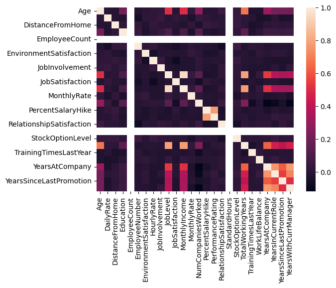

```python
sns.heatmap(employees.corr())
```